# 5_1_Time_Series_Decomposition_Intro

# References

1. Hyndman, R.J., & Athanasopoulos, G., 2021. *Forecasting: principles and practice*. 3rd edition.
2. Kourentzes, Nikolaus. *Additive and multiplicative seasonality - can you identify them correctly?* [Link](https://kourentzes.com/forecasting/2014/11/09/additive-and-multiplicative-seasonality/#comments)

# Packages

```r
library(fpp3)
library(seasonal)
```

# Additive vs. Multiplicative decomposition

A time series mightbe decomposed, in general terms, in three different components:

- A seasonal component $S_t$
- A trend-cycle component $T_t$
  - Some authors separate the trend and cycle component. Here **we consider trend-cycle** because the usual decomposition algorithms extract them together, not separately.
- The remainder component $R_t$

Typically we distinguish between **two types of decomposition schemes**:

- An **additive scheme**:

$$\boxed{y_t = S_t + T_t + R_t}$$

- A **multiplicative scheme**:

$$\boxed{y_t = S_t\times{T_t}\times{R_t}} \\
or \\
\boxed{\log{y_t}= log{S_t} + \log{T_t} + \log{R_t}}$$

- **Additive scheme**
  - The variation around the trend-cycle, of the seasonal pattern, **does NOT vary with the level of the time series (with the trend component value).**
- **Multiplicative scheme**
  - The variation around the trend-cycle, of the seasonal pattern, appears to be **proportional to the level of the time series (to the trend component value).**

## Two examples known to us

We will explore several methods for obtaining the components of the time series throughout the chapter, but let us first have a look at two examples.

### Additive scheme

We will work with the number of persons employed in retail as shown in Figure 3.5. We can see the monthly number of persons in thousands employed in the retail sector across the US since 1990:

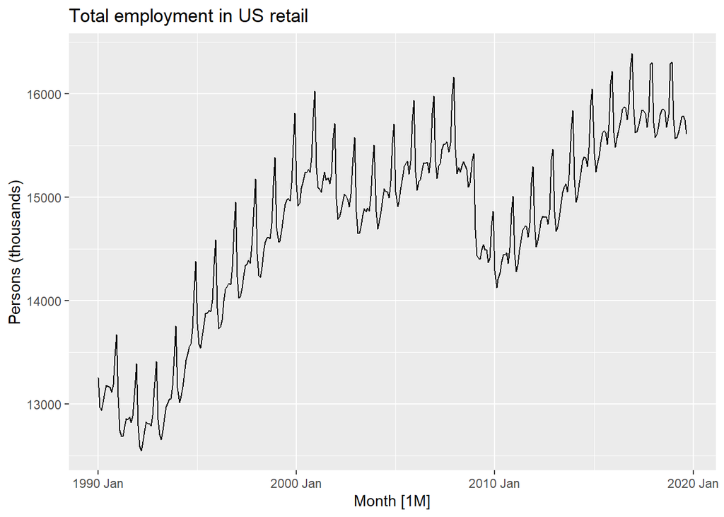

```r
us_retail_employment <- us_employment %>%
  filter(year(Month) >= 1990, Title == "Retail Trade") %>%
  select(-Series_ID)
autoplot(us_retail_employment, Employed) +
  labs(y = "Persons (thousands)",
       title = "Total employment in US retail")
```

As you can see in the graph above, the level of the seasonality (the amplitude of the seasonal peaks) does not seem to change with the level of the series (with the level of the trend). Let us inspect it more closely.

With this code we can obtain the components using the STL decomposition method (more on that and on why we pick this method for this additive scheme later in the chapter):

```r
dcmp <- us_retail_employment %>%
  model(stl = STL(Employed))

components(dcmp)
```

```
## # A dable: 357 x 7 [1M]
## # Key:     .model [1]
## # :        Employed = trend + season_year + remainder
##    .model    Month Employed  trend season_year remainder season_adjust
##    <chr>     <mth>    <dbl>  <dbl>       <dbl>     <dbl>         <dbl>
##  1 stl    1990 Jan   13256. 13288.      -33.0      0.836        13289.
##  2 stl    1990 Feb   12966. 13269.     -258.     -44.6          13224.
##  3 stl    1990 Mar   12938. 13250.     -290.     -22.1          13228.
##  4 stl    1990 Apr   13012. 13231.     -220.       1.05         13232.
##  5 stl    1990 May   13108. 13211.     -114.      11.3          13223.
##  6 stl    1990 Jun   13183. 13192.      -24.3     15.5          13207.
##  7 stl    1990 Jul   13170. 13172.      -23.2     21.6          13193.
##  8 stl    1990 Aug   13160. 13151.       -9.52    17.8          13169.
##  9 stl    1990 Sep   13113. 13131.      -39.5     22.0          13153.
## 10 stl    1990 Oct   13185. 13110.       61.6     13.2          13124.
## # ... with 347 more rows
```

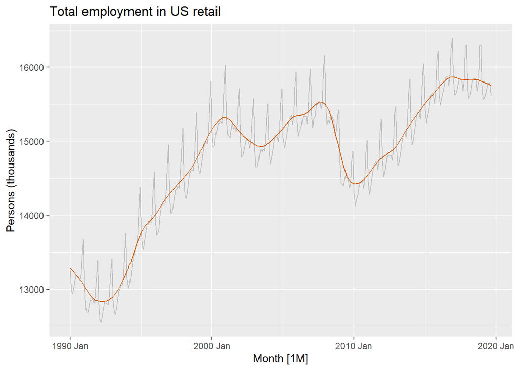

```r
components(dcmp) %>%
  as_tsibble() %>%
  autoplot(Employed, colour="gray") +
  geom_line(aes(y=trend), colour = "#D55E00") +
  labs(
    y = "Persons (thousands)",
    title = "Total employment in US retail"
  )
```

Overlaying the trend, we can visually confirm that the amplitude of the seasonal peaks does not seem to change with the level of the series (with the level of the trend).

Using autoplot, we can have a look at the components:

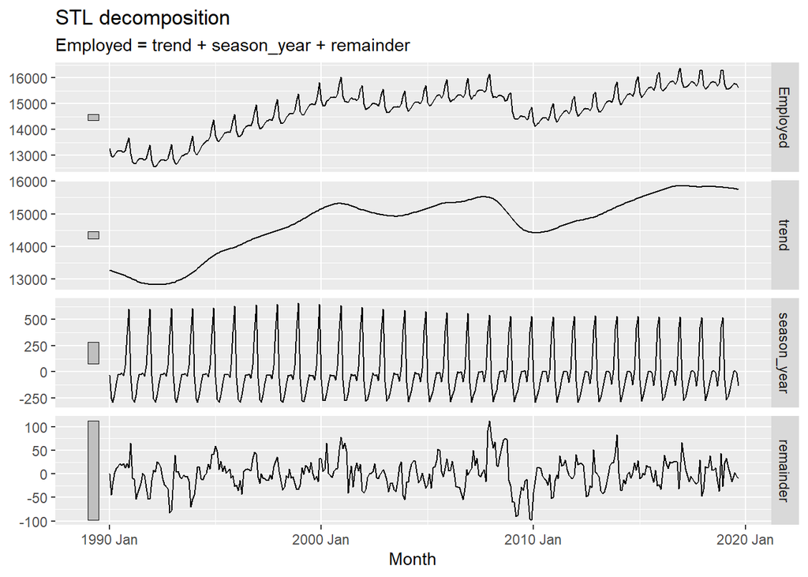

```r
components(dcmp) %>% autoplot()
```

### Multiplicative scheme:

Let us resort again to the monthly medicare Australian prescription data, because it shows a clear multiplicative scheme. We can see that in the plot below, where it is clear that the amplitude of the seasonal oscillations increases as the level of the trend grows.

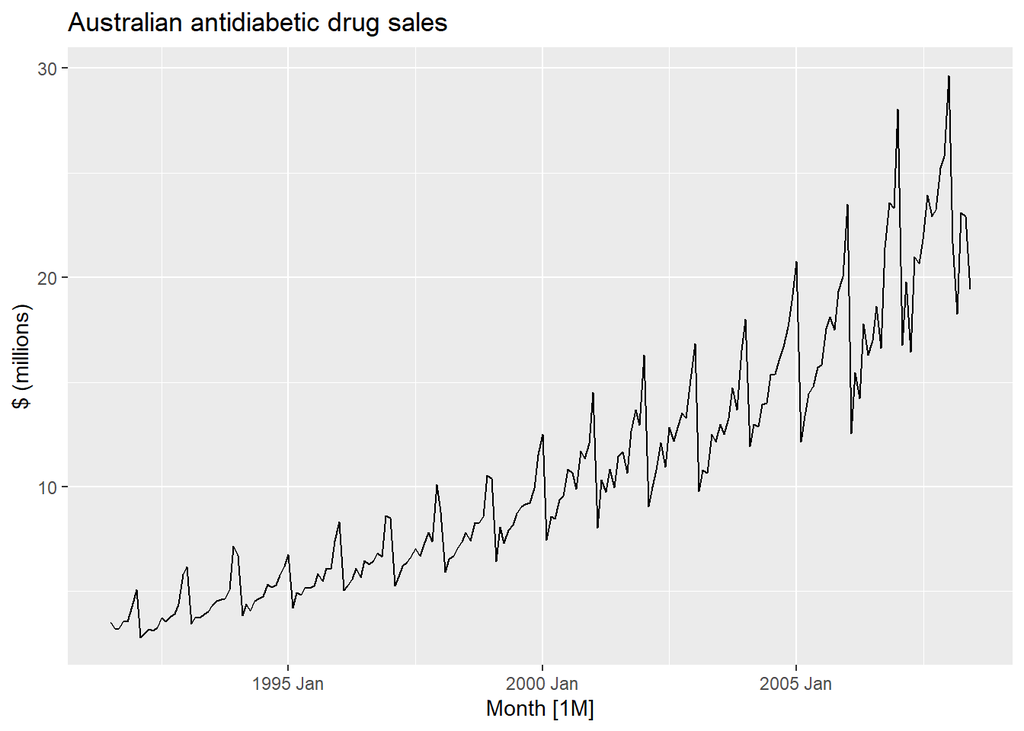

```r
PBS %>%
  filter(ATC2 == "A10") %>%
  select(Month, Concession, Type, Cost) %>%
  summarise(TotalC = sum(Cost)) %>%
  mutate(Cost = TotalC / 1e6) -> a10

autoplot(a10, Cost) +
  labs(y = "$ (millions)",
       title = "Australian antidiabetic drug sales")
```

```r
a10
```

```
## # A tsibble: 204 x 3 [1M]
##       Month  TotalC  Cost
##       <mth>   <dbl> <dbl>
##  1 1991 Jul 3526591  3.53
##  2 1991 Aug 3180891  3.18
##  3 1991 Sep 3252221  3.25
##  4 1991 Oct 3611003  3.61
##  5 1991 Nov 3565869  3.57
##  6 1991 Dec 4306371  4.31
##  7 1992 Jan 5088335  5.09
##  8 1992 Feb 2814520  2.81
##  9 1992 Mar 2985811  2.99
## 10 1992 Apr 3204780  3.20
## # ... with 194 more rows
```

With this code we can obtain the components using X11 decomposition. We use this method because the series is multiplicative (more about that later in the chapter):

```r
x11_dcmp <- a10 %>%
  model(x11 = X_13ARIMA_SEATS(Cost ~ x11())) %>%
  components()
```

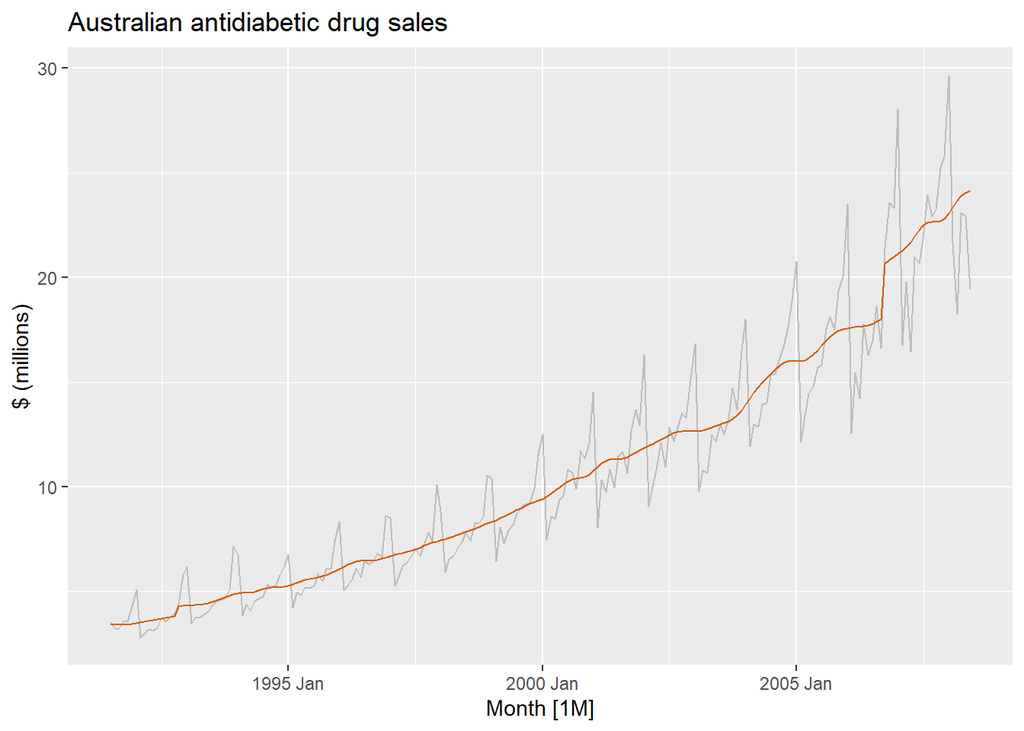

```r
x11_dcmp %>%
  as_tsibble() %>%
  autoplot(Cost, colour="gray") +
  geom_line(aes(y=trend), colour = "#D55E00") +
  labs(
    y = "$ (millions)",
    title = "Australian antidiabetic drug sales"
  )
```

Overlaying the trend shows even more clearly that the amplitude of the seasonal oscillations increases with the level of the trend.

We can depict the components using autoplot:

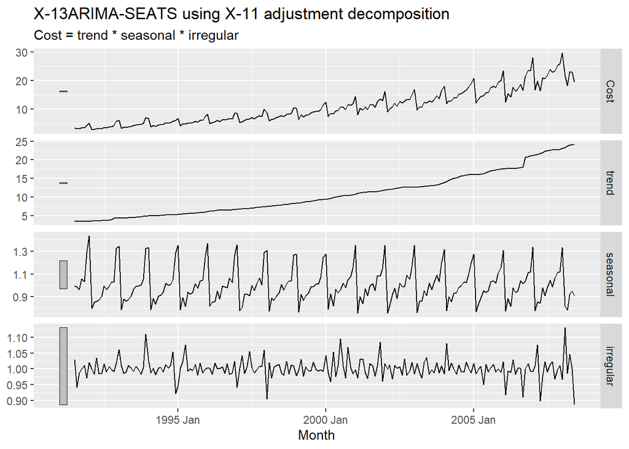

```r
x11_dcmp %>% autoplot()
```

### Multiplicative scheme under different transformations:

Let us look at the effect of applying different transformations of increasing strength to stabilize variations.

Specifically we will apply the following transformations to our variable. They have been ordered by their increasing strength (from weakest to strongest):

- **square root** transformation
- **cubic root** transformation
- **log** transformation
- **inverse** transformation

The following code snippet generates one column for each of the transformations (transformations applied to the variable “Cost”):

```r
a10 <- mutate(a10, sqrt_cost = sqrt(Cost), cbrt_cost = Cost^(1/3), log_cost = log(Cost), inv_cost = -1/Cost)
a10
```

```
## # A tsibble: 204 x 7 [1M]
##       Month  TotalC  Cost sqrt_cost cbrt_cost log_cost inv_cost
##       <mth>   <dbl> <dbl>     <dbl>     <dbl>    <dbl>    <dbl>
##  1 1991 Jul 3526591  3.53      1.88      1.52     1.26   -0.284
##  2 1991 Aug 3180891  3.18      1.78      1.47     1.16   -0.314
##  3 1991 Sep 3252221  3.25      1.80      1.48     1.18   -0.307
##  4 1991 Oct 3611003  3.61      1.90      1.53     1.28   -0.277
##  5 1991 Nov 3565869  3.57      1.89      1.53     1.27   -0.280
##  6 1991 Dec 4306371  4.31      2.08      1.63     1.46   -0.232
##  7 1992 Jan 5088335  5.09      2.26      1.72     1.63   -0.197
##  8 1992 Feb 2814520  2.81      1.68      1.41     1.03   -0.355
##  9 1992 Mar 2985811  2.99      1.73      1.44     1.09   -0.335
## 10 1992 Apr 3204780  3.20      1.79      1.47     1.16   -0.312
## # ... with 194 more rows
```

Now let us explore the effect of each transformation in the data. I simply want to plot all the four columns I just created in the tsibble. In order to avoid code repetition, I want to do this using a for loop to iterate through these columns. This for loop can be a bit complicated and it is not the focus of the class. Please focus on its output rather than in its inner mechanincs (or at least do not spend to much time wondering about it).

The same output could be produced executing the code for each graph separately and, despite that being *spaghetti code* practice in data science, it is good enough for the purposes of this course.

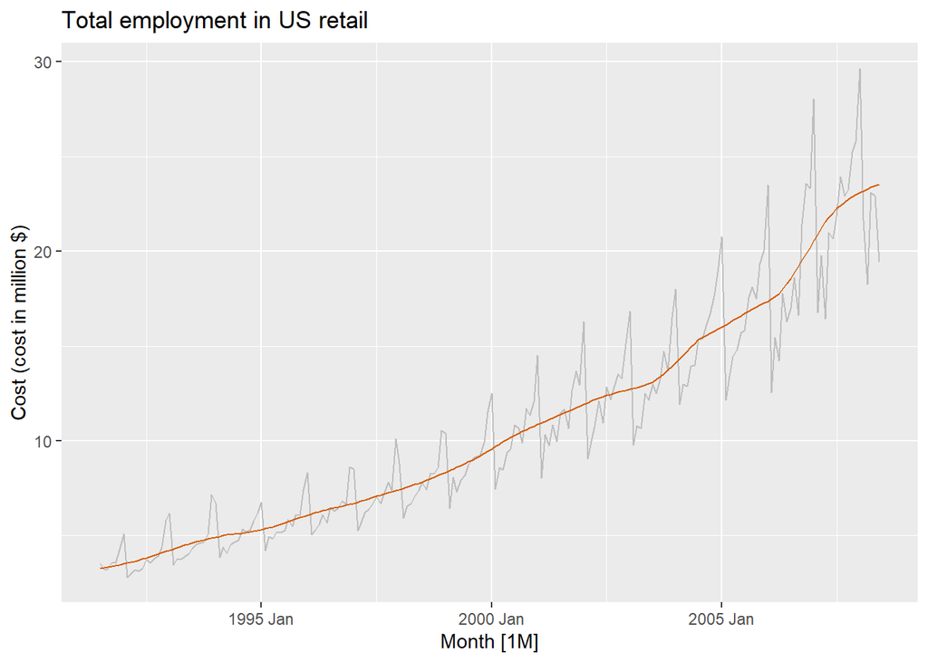

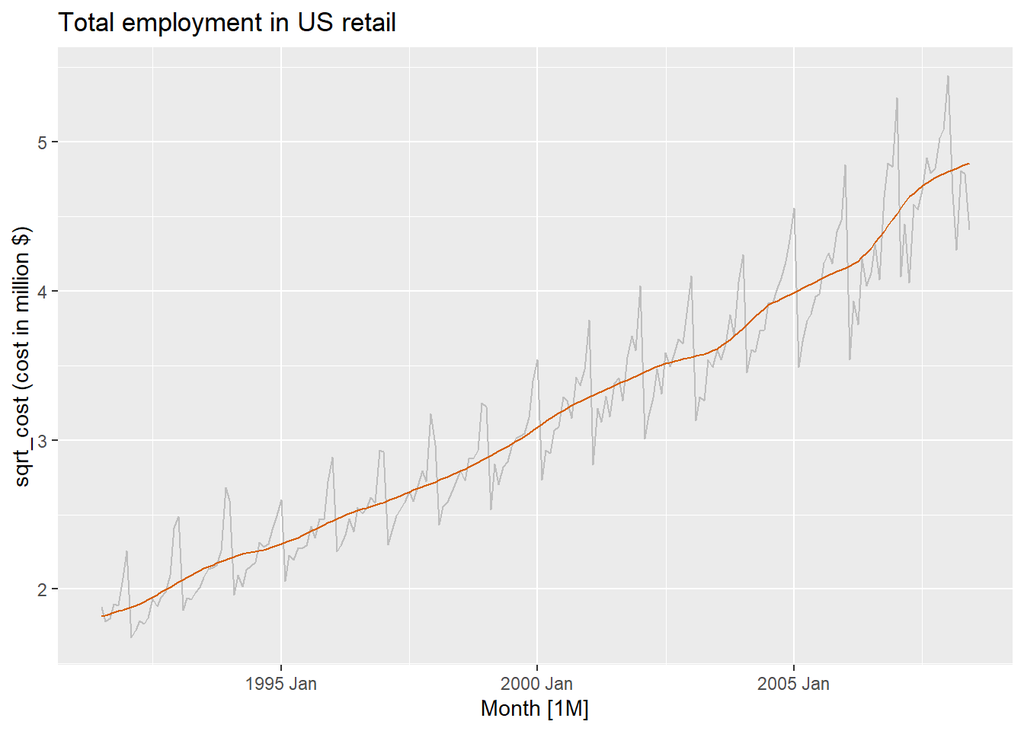

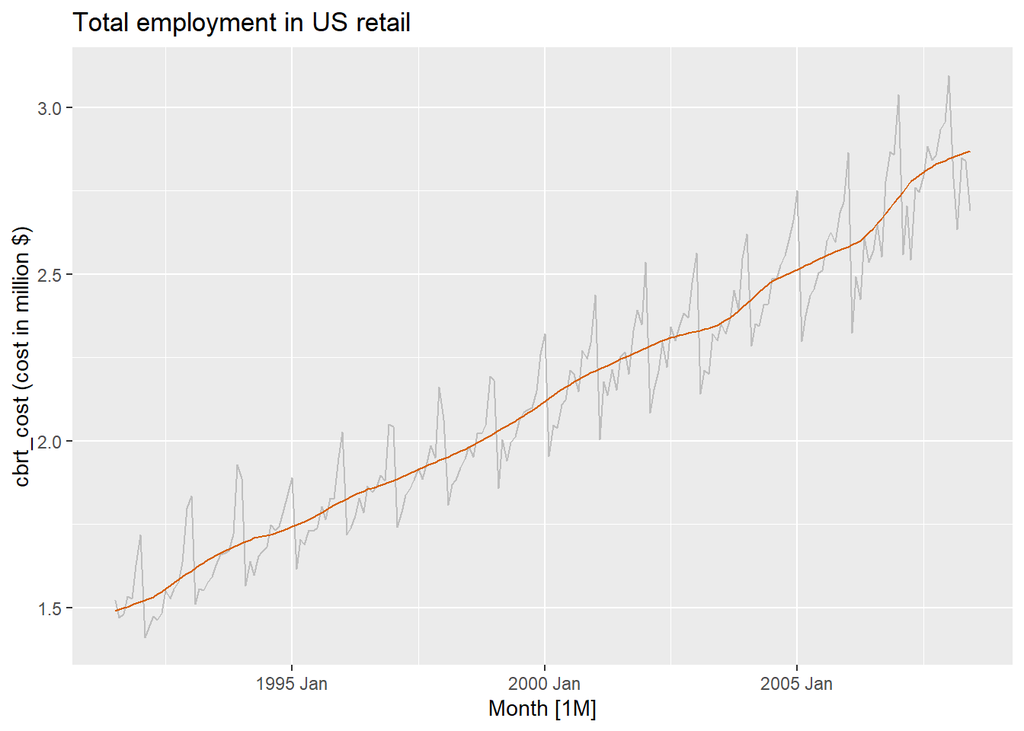

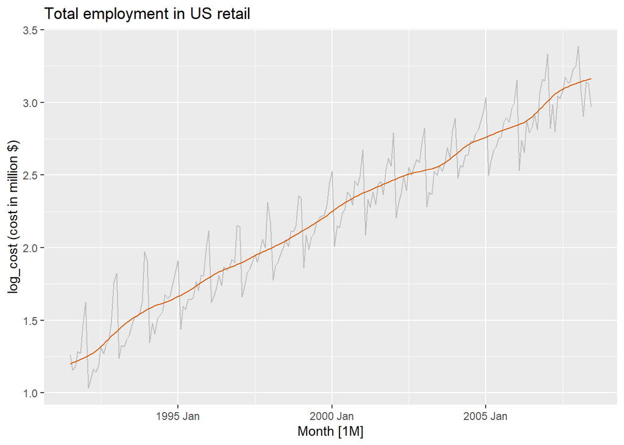

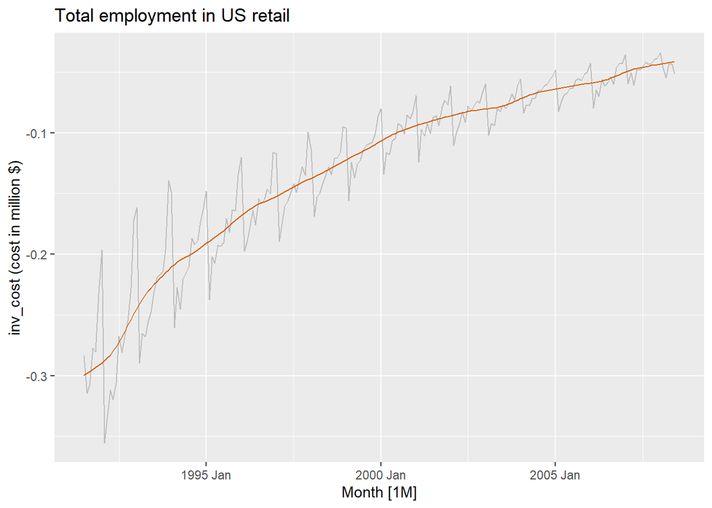

```r
for (col_name in colnames(select(as_tibble(a10), Cost, sqrt_cost:inv_cost))){

  # The line is complicated particularly due to the !! operator
  # Do not worry too much about this line, you can do this for each
  # of the variables separately as shown in the previous examples
  # Explaining this line is beyond the scope of this course.
  comps <- components(model(a10, stl = STL(!!sym(col_name))))

  # Convert to a tsibble
  comps <- as_tsibble(comps)

  # .data is a reference to comps, which is passed to autoplot
  print(autoplot(comps, .data[[col_name]], colour="gray") +

          geom_line(aes(y=trend), colour = "#D55E00") +

          labs(
            y = paste(col_name, "(cost in million $)"),
            title = "Total employment in US retail"
          )
  )
}
```

We can immediately observe that the `sqrt` and `cbrt` transformations even out the difference in magnitude of the different seasonal patterns to some extent, but it is the `log` transformation the one that yields the best effect in this case. The `inverse` transformation simply inverts the pattern, so that now lower levels of the trend correspond to greater fluctuations in the seasonal pattern.

#### Units when performing a transformation:

**Beware that, after performing each transformation we are not dealing with the cost in million dollars anymore**.

The original variable had units of millions of dollars, so the transformed variables would have units of:

- **square-root**: $millions^{1/2}$,
- **cubic root**: $millions^{1/3}$
- **log**: $log(millions)$
- **inverse**: $millions^{-1}$

This is important because **making a transformation might make the data more palatable to the forecasting model we are trying to build** but **it comes at a big price: the reduction of its interpretability**-

- Once we build a forecasting model using this transformed data and performed our forecast, we would have to revert our results to the original varible using the inverse transformation.
- The **log() transformation has the best interpretability of the above transformations.** See the video `logarithmic_scales` on the supplementary math topics to understand this in depth.

#### Note about the for loop used:

The for loop used to print all the transformed graph, which involves some complex statements to turn strings into expressions we can evaluate, is not something you need to focus on right now. Instead you could have just computed each of the graphs separately. For example:

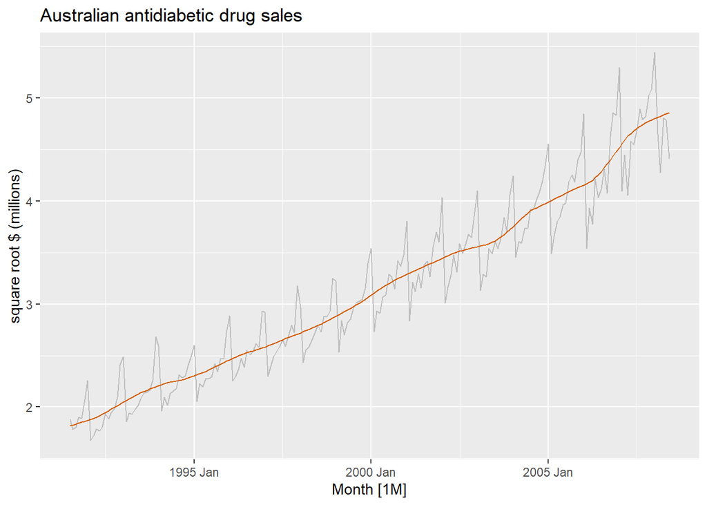

```r
dcmp <- a10 %>%
  model(stl = STL(sqrt_cost))

components(dcmp) %>%
  as_tsibble() %>%
  autoplot(sqrt_cost, colour="gray") +
  geom_line(aes(y=trend), colour = "#D55E00") +
  labs(
    y = "square root $ (millions)",
    title = "Australian antidiabetic drug sales"
  )
```

## Further visual examples of additive vs. multiplicative

The following image clarifies the basic difference between the additive and multiplicative decomposition schemes. It has been borrowed from reference [2].

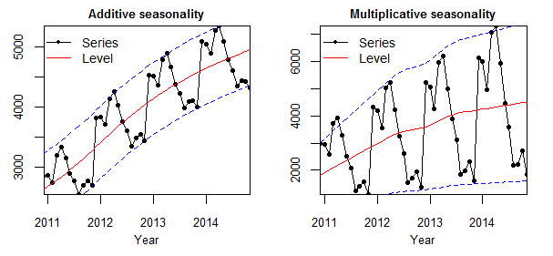

Figure 1: Multiplicative vs additive schemes. From reference [2].

In **reference [2]**, there is an **interesting interactive game where you can practice to recognize visual cues in additive and multiplicative schemes**. I strongly encourage you to spend some minutes doing this.

## Mathematical identification of additive vs multiplicative schemes

Visual inspection is a first approach to assessing the scheme type and it is interesting for developing your intuition as analysts. However, when you are faced with a large batch of time series you need to process, it is definitely not the best approach. There are different ways in which the type of scheme could be evaluated.

One such way could be to:

1. Decompose the series using a method that is appropriate for additive schemes and a method appropriate for a multiplicative scheme.
2. Assess the error of each method. For example, assessing the amount of autocorrelation in the remainder of each decomposition.

Another possibility would be to:

1. Fit an exponential smoothing for an additive scheme
2. Fit an exponential smoothing for a multiplicative scheme.
3. Compare their Akaike Information Criteria (AIC) to see which fits best

When we are familiar with decomposition techniques at the end of the chapter, we can perform such an example.

## Mixed schemes:

Reality is not always so black and white. Sometimes we have mixed schemes, although we will not deal with them in this course. One such schemes could be as follows:

- Trend-cycle and seasonality components relating in a multiplicative manner.
- The remainder component superimposed in an additive scheme.

$$\boxed{y_t = (S_t \times T_t ) + R_t}$$

This scheme is relevant when:

- The irregular component of the oscillations $R_t$ does not grow with the level of the time series (and therefore is super-imposed in an additive manner)
- The seasonal component grows with the level of the time series, and therefore is combined with the trend in a multiplicative manner.

# Mathematical transformations

In the context of this course we will perform mathematical transformations to **make data more palatable for the forecasting models we want to build.** When a model does not behave good enough, we will have two general alternatives to improve it:

1. Refine the model (include external variables, use a model that can consider cyclicity better…)
2. Simplify the data or transform it to make it more palatable for the model

The transformation we are going to see are **useful if the data shows variation that increases or decreases with the level of the series** (with the level of its trend). The notation we will follow is:

- Original series: $y_1,\;...,y_t$.
- Transformed series: $w_1,\;...,w_t$.

**Recall from the previous note that all these transformation come at the price of interpretability** (perhaps with the exception of logarithms). They actually change the units of what we are studying.

## log() transformations

$$\boxed{w_t = log(y_t)}$$

**NOTE:** the **log** function returns the **natural logarithm**. Whenever you use software that involved logarithmic functions, check the documentation or run some cases to be certain about the base being used. * **Natural logarithms (base e)** are actually the reference for the rest of the logarithms. There are multiple reasons for this, but essentially the number $e$ arises in many different situations (limits, infinite series, differential equations, complex variable…) as a limit or sum that makes it the “natural” reference for the rest of the exponentials and logarithms.

**SIDE NOTE**: any logarithm or exponential can be expressed in terms of **e** using the following formulas (NOT necessary to know these formulas by heart).

- $a^x = e^{xLn(a)}$
- $log_a(x) = \frac{log_b(x)}{log_b(a)}$

In the example of the Australian antidiabetic drug sales we saw earlier, this log() transformation made the oscillations around the trend very uniform-

### Interpretation of logarithms

Changes in a log value are relative (or percentage changes) on the original scale. Example with log 10:

- An increase of 1 on the $log_10$ scale corresponds to multiplying by 10 on the original scale.
- See the video on “supplementary math topics” regarding the logarithmic scale for further details if this is unknown to you.

NOTE:

- $log(1+x)$ can be useful for data with zeros. The `log1p()` corresponds to `log(1+x)`
  - If x is very small (< 1 and close to 0), its logarithm rapidly decays to $-\infty$
  - We want to shift this data to the viccinity of 1, where the logarithm is 0 and its slope is 1.

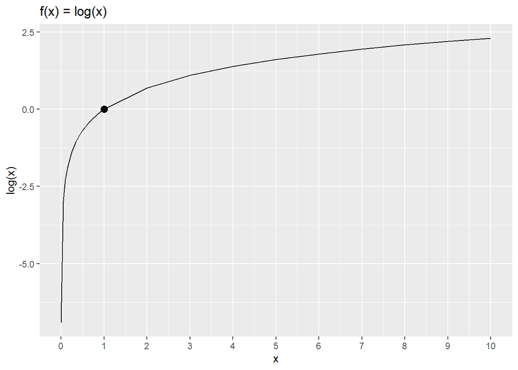

## Power transformations

$$\boxed{w_t = y_t^p}$$

They are not as interpretable as the logarithmic transformation.

For **p < 1** they also tend to stabilize seasonal and random variations around the trend, as we saw in the example of the adiabatic anti-drug sales.

## Box-Cox transformations

This transformation is defined to include both logarithms and power transformations depending on the parameter $\lambda$.

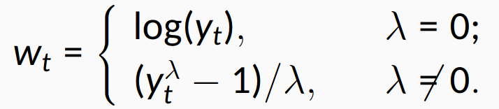

Figure 2: Box Cox transformation.

Again, the transformation attempts to stabilize the seasonal fluctuations and random variations around the trend level.

- The logarithm in a Box-Cox transformation is **always a natural logarithm**.
  - $\lambda = 1$: no substantial transformation
  - $\lambda = 0$: transformation equivalent to a natural logarithm.
  - $\lambda = 1/2$: Square root + linear transformation
  - $\lambda = 1/3$: Cubic root + linear transformation
  - $\lambda = -1$: Inverse transformation + 1
- Caveats when using this transformation
  - **If some data are zero or negative, use $\lambda > 0$
  - Always check your results depicting the time series.
  - A low value of $\lambda$ can result in extremely large prediction intervals.

Let us look first at an example of what it actually makes to the data,

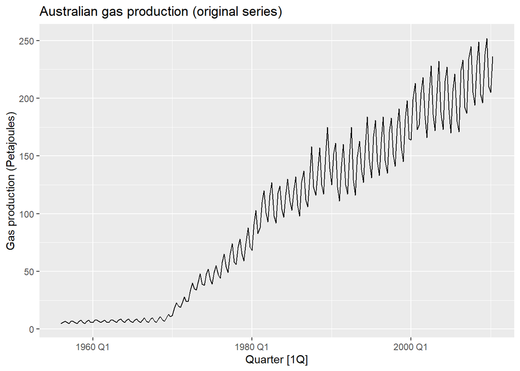

```r
autoplot(aus_production, Gas) +
  labs(y = "Gas production (Petajoules)",
     title = "Australian gas production (original series)")
```

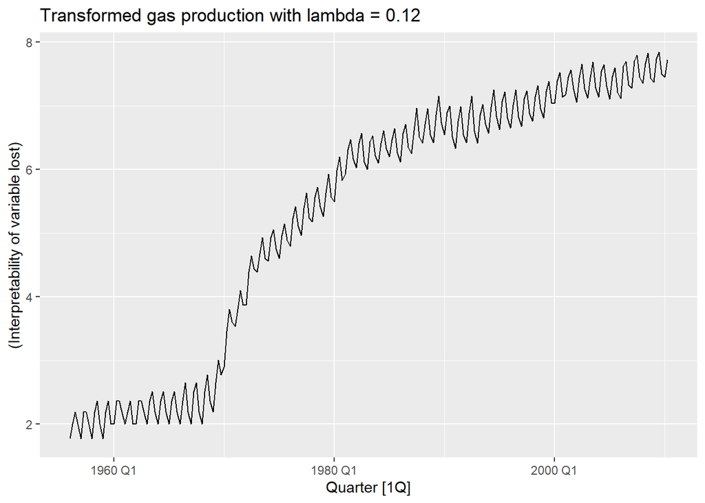

```r
aus_production %>%
  autoplot(box_cox(Gas, 0.12)) +
  labs(y = "(Interpretability of variable lost)",
       title = "Transformed gas production with lambda = 0.12")
```

**If the data is such that its seasonal oscillations are proportional to the level of the trend**, it will many times be possible to find a lambda for the box-cox transformation that is adequate to make these oscillations uniform.

### Caveat of Box-Plot like transformations

Power transformations (such as the log-plot transformation) **require the variability of the series to vary proportionally to the level of the series**.

Let us look at data about the production of gas in Canada:

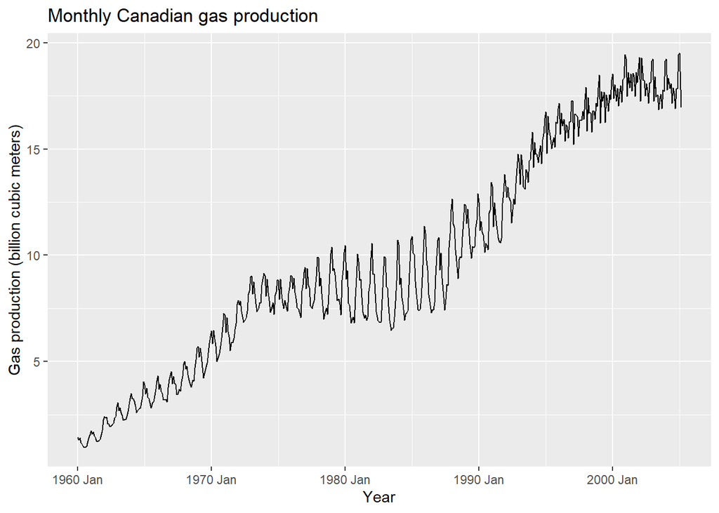

```r
canadian_gas %>%
  autoplot(Volume) +
  labs(
    x = "Year", y = "Gas production (billion cubic meters)",
    title = "Monthly Canadian gas production"
  )
```

- The **variation of the series is not proportional to the amount of gas produced in Canada.**
  - **For small and large production levels:** small variations in the seasonal pattern
  - **Moderate production levels:** between 1975 and 1990. The variation in the seasonal pattern is large.

In this case, **the transformations we are studying would not help make the data simpler for a model**, because the variability of the seasonal pattern is not proportional to the level of the trend.

### Guerrero feautre to pick a variable for the parameter lambda

The `guerrero` feature can be used to choose a value of lambda appropriate for the box-cox transformation

```r
lambda <- aus_production %>%
  features(Gas, features = guerrero) %>%
  pull(lambda_guerrero)

lambda
```

```
## [1] 0.1205077
```

The lambda given by this feature is 0.12, the value we had previously used.

## Some notes on transformations

- **Often no transformation is needed** and we are able to produce a good forecast with the original data.
- Transformations that have **good interpretability (such as log transformations) are preferred if they work well enough.**
- Transformations **can have a very large effect on Prediction Intervals**.
- Transformations **must be reversed to obtain forecasts on the original scale.**

## EXAMPLES

For each of the following series, make a graph of the data. If transforming seems appropriate, do so and describe the effect.

- United states GDP from `global economy`
- Slaughter of Victorian “Bulls, bullocks and steers” in `aus_livestock`
- Victorian Electricity Demand from `vic_elec`
- Tobacco from aus_production
- The following retail series:

```r
retail_series <- aus_retail %>%
  filter(`Series ID` == "A3349767W")
```

### United states gdp from global economy:

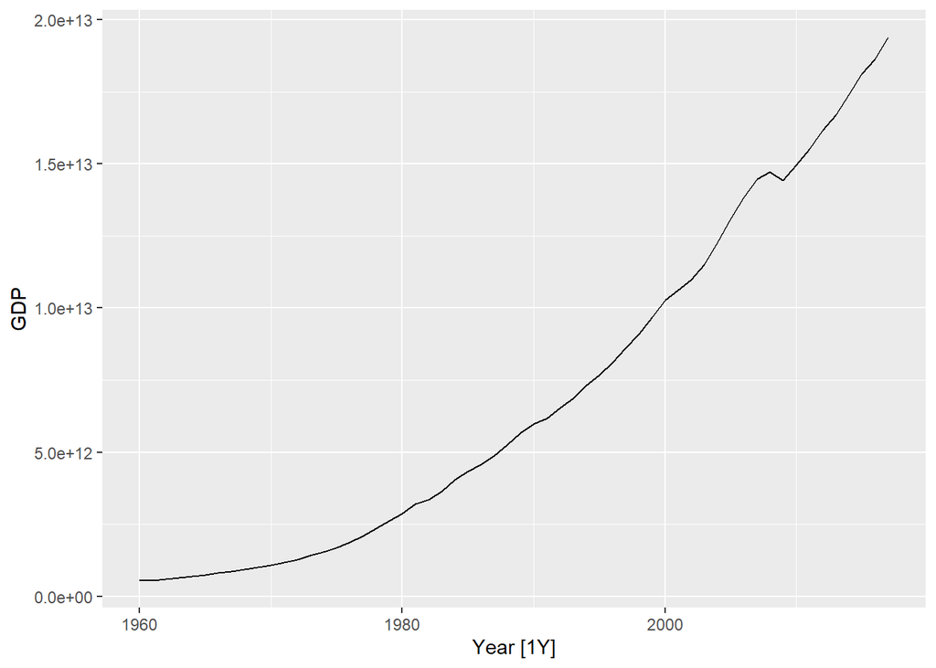

```r
us_economy <- global_economy %>%
  filter(Country == "United States")
us_economy %>%
  autoplot(GDP)
```

The trend is exponential. We could linearize it with a transformation

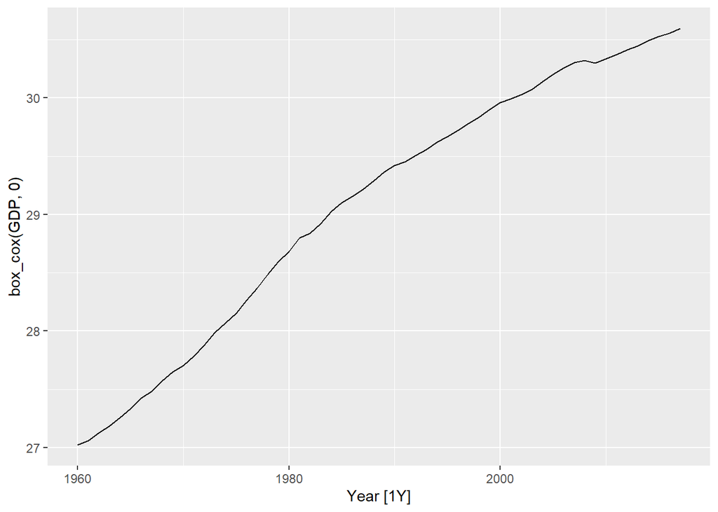

```r
us_economy %>%
  autoplot(box_cox(GDP, 0))
```

A log transformation (Box plot with $\lambda = 0$) seems to be too strong. Let’s see what Guerrero’s feature suggests:

```r
lambda <- us_economy %>%
  features(GDP, features = guerrero) %>%
  pull(lambda_guerrero)

lambda
```

```
## [1] 0.2819443
```

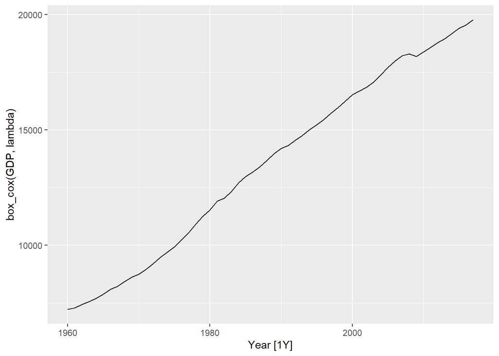

```r
us_economy %>%
  autoplot(box_cox(GDP, lambda))
```

**Question** would you apply this transformation to your data?

It does not seem like a good idea because we have lost all the interpretability (using $\lambda = 0.28$) and have not gained much in return. If it were a logarithmic transformation (good interpretability) then we could consider it.

### Slaughter of Victorian “Bulls, bullocks and steers”

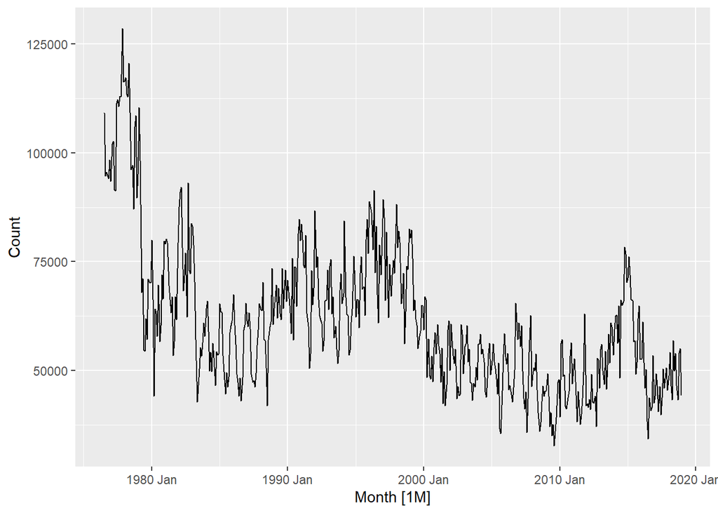

```r
vic_bulls <- aus_livestock %>%
  filter(State == "Victoria", Animal == "Bulls, bullocks and steers")
vic_bulls %>%
  autoplot(Count)
```

The variation of the series appears to slightly vary with the numbers of bulls slaughtered. A transformation could be useful.

Let us see what the guerrero feature suggests:

```r
vic_bulls %>%
  features(Count, features = guerrero)
```

```
## # A tibble: 1 x 3
##   Animal                     State    lambda_guerrero
##   <fct>                      <fct>              <dbl>
## 1 Bulls, bullocks and steers Victoria         -0.0720
```

**Question**: should we use this value? Can you think of another value that might be best?

since the value is really close to 0 (-0.07) and the limit case of lambda = 0 is a logarithmic transformation with very good interpretability, we should use the logarithmic transformation instead. Lets check those results

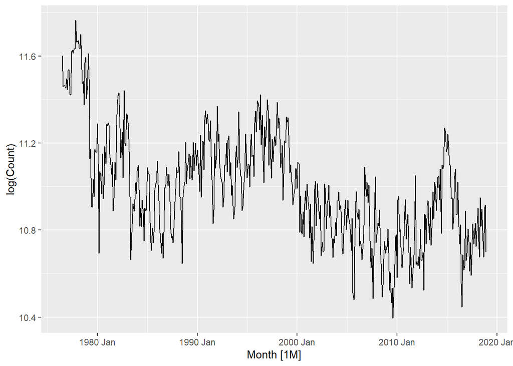

```r
vic_bulls %>%
  autoplot(log(Count))
```

A log transformation ($\lambda = 0$) is pretty close and has much better interpretability.

### Tobacco from aus_production

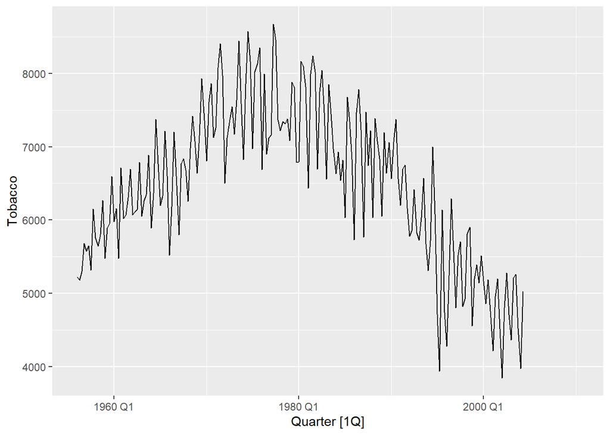

```r
aus_production %>%
  autoplot(Tobacco)
```

This variation in this series appears to be mostly constant across different levels of the series.

Lets look at guerrero’s suggestion:

```r
lambda <- aus_production %>%
  features(Tobacco, features = guerrero) %>%
  pull(lambda_guerrero)

lambda
```

```
## [1] 0.9289402
```

The value is indeed really close to 1, a value of lambda for which the transformation barely has an effect. Let us inspect the result of applying such a transformation:

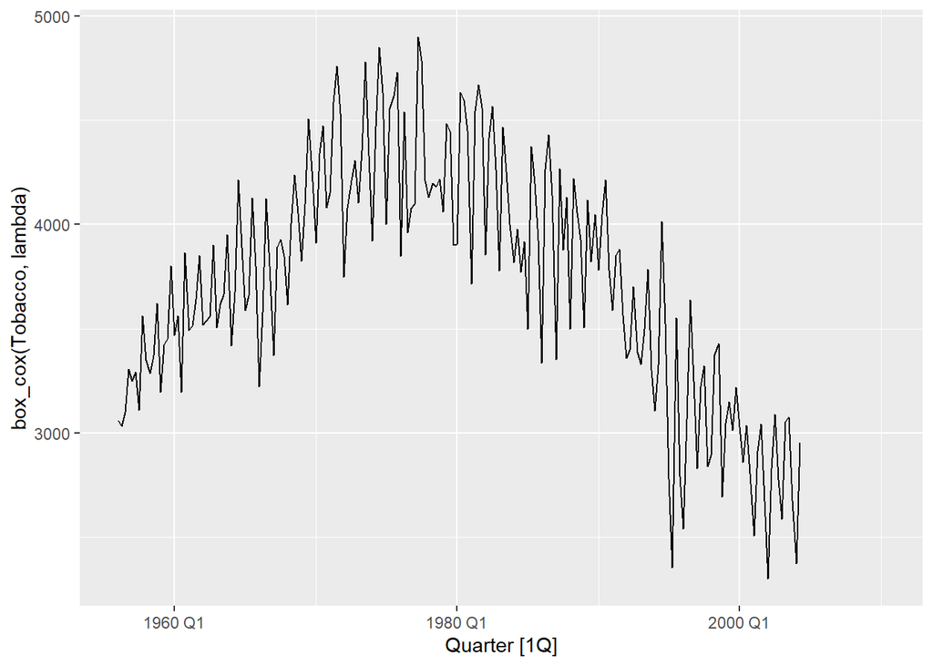

```r
aus_production %>%
  autoplot(box_cox(Tobacco, lambda))
```

**Question** would you perform this transformation?

You should not perform this transformation because it does not result in any noticeable gain but it completely ruins the interpretability.

### Retail series

```
## Plot variable not specified, automatically selected `.vars = Turnover`
```

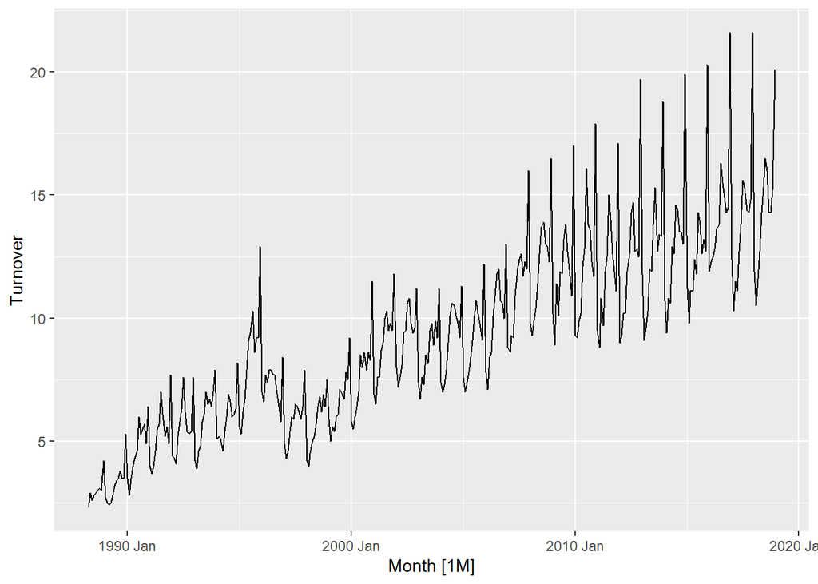

```r
retail_series <- aus_retail %>%
  filter(`Series ID` == "A3349767W")

autoplot(retail_series)
```

The variation appears to be proportional to the level of the series.

Lets inspect guerrero’s suggestion

```r
retail_series %>%
  features(Turnover, features = guerrero)
```

```
## # A tibble: 1 x 3
##   State              Industry                                    lambda_guerrero
##   <chr>              <chr>                                                 <dbl>
## 1 Northern Territory Clothing, footwear and personal accessory ~         -0.0223
```

**Question** given this value of lambda, what would you do?

Again, since it is a value of lambda really close to the limit case of 0 (logarithmic transformation), which has a much better interpretability, we should pick the logarithmic transformation instead.

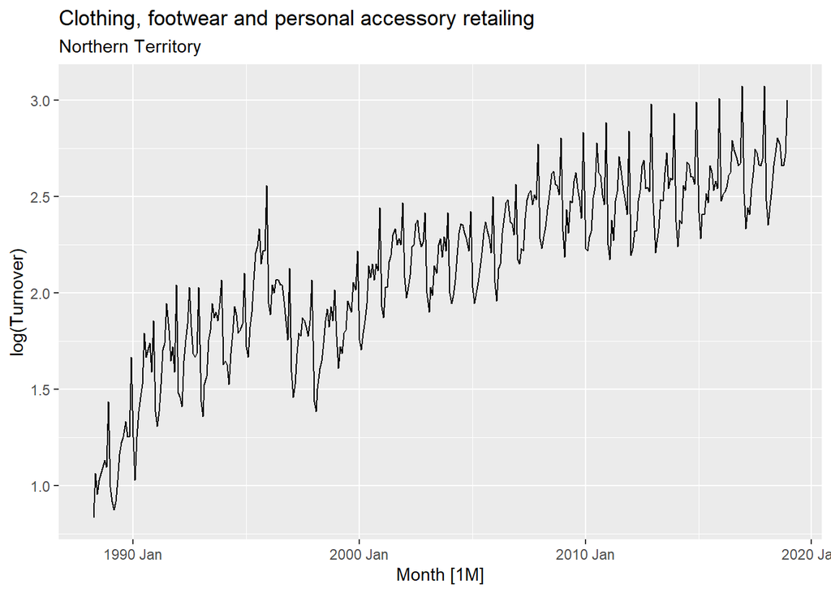

```r
retail_series %>%
  autoplot(log(Turnover)) +
  labs(
    title = retail_series$Industry[1],
    subtitle = retail_series$State[1]
  )
```

Upon inspection we can see that the transformation does indeed reduce the variability of the oscillations around the trend.